# MSstatsLiP Workflow: An example workflow and analysis of the MSstatsLiP package

#### 2.2 Tryptic barplot

MSstatsLiP has a wide variety of plotting functionality to analysis and assess the results of experiments. Here we plot the number of half vs fully tryptic peptides per replicate.

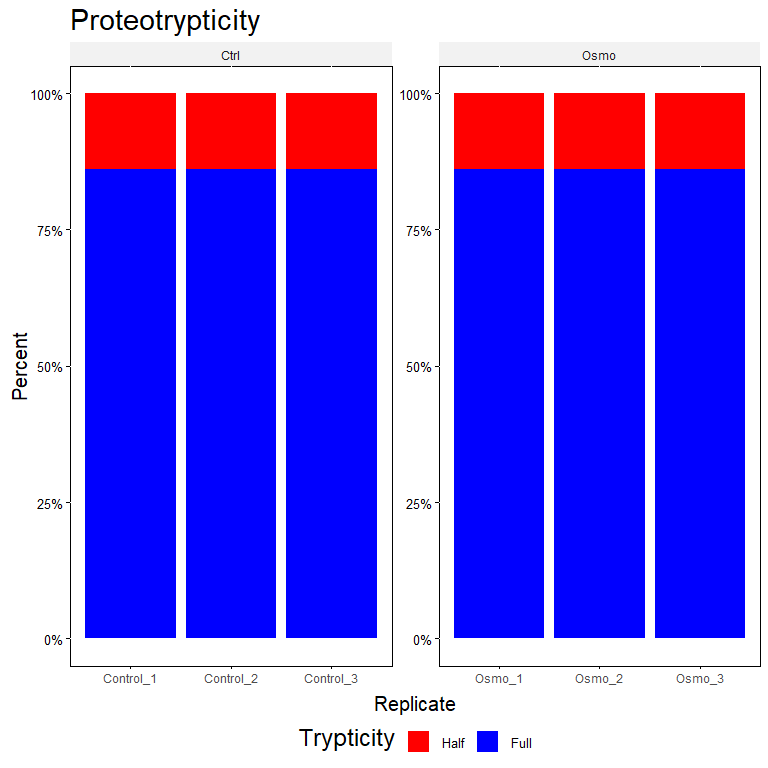

```r
trypticHistogramLiP(MSstatsLiP_Summarized,
                    "../inst/extdata/ExampleFastaFile.fasta",
                    color_scale = "bright",
                    address = FALSE)
```

#### 2.3 Run Correlation Plot

MSstatsLiP also provides a function to plot run correlation.

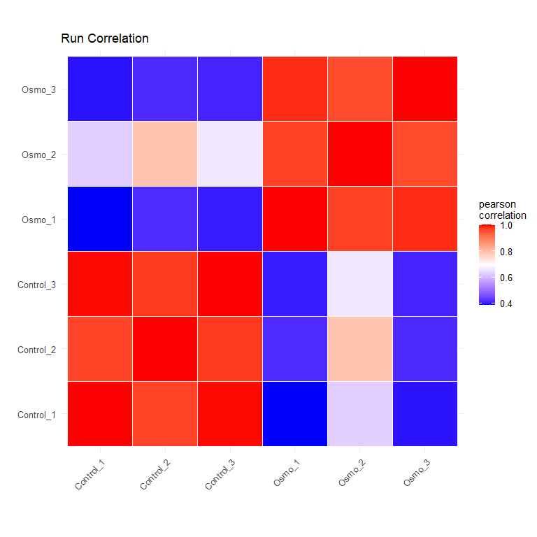

```r
correlationPlotLiP(MSstatsLiP_Summarized, address = FALSE)
```

#### 2.4 Coefficient of Variation

Here we provide a simple script to examine the coefficient of variance between conditions

```
#> Warning: Removed 12 rows containing non-finite values (stat_ydensity).
```

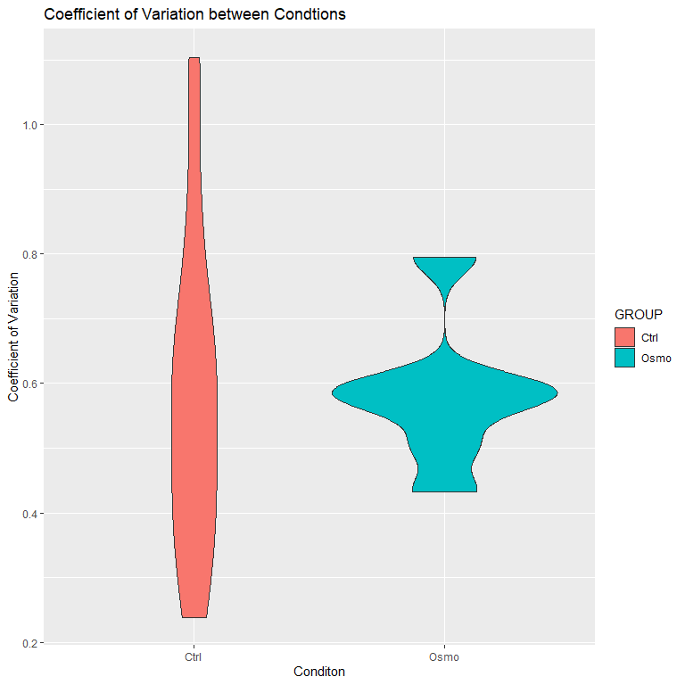

```r
MSstatsLiP_Summarized[["LiP"]]$FeatureLevelData %>%
  group_by(PEPTIDE, GROUP) %>%
  summarize(cv = sd(INTENSITY) / mean(INTENSITY)) %>%
  ggplot() + geom_violin(aes(x = GROUP, y = cv, fill = GROUP)) +
  labs(title = "Coefficient of Variation between Condtions",
       y = "Coefficient of Variation", x = "Conditon")
```

#### 2.5 QCPlot

The following plots are used to view the summarized data and check for potential systemic issues.

```
#> Drew the Quality Contol plot(boxplot) for all ptms/proteins.
```

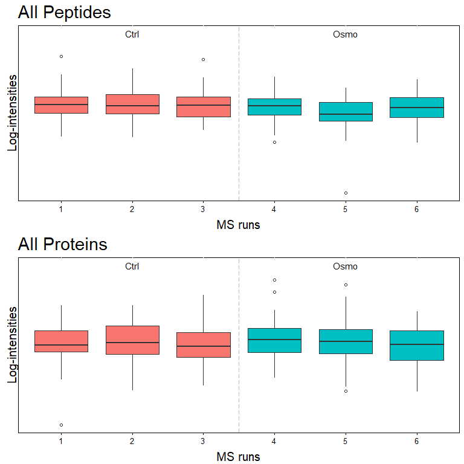

```r
## Quality Control Plot
dataProcessPlotsLiP(MSstatsLiP_Summarized,
                    type = 'QCPLOT',
                    which.Peptide = "allonly",
                    address = FALSE)
```

#### 2.6 Profile Plot

```
#> Drew the Profile plot for P14164_ILQNDLK (1 of 1)
```

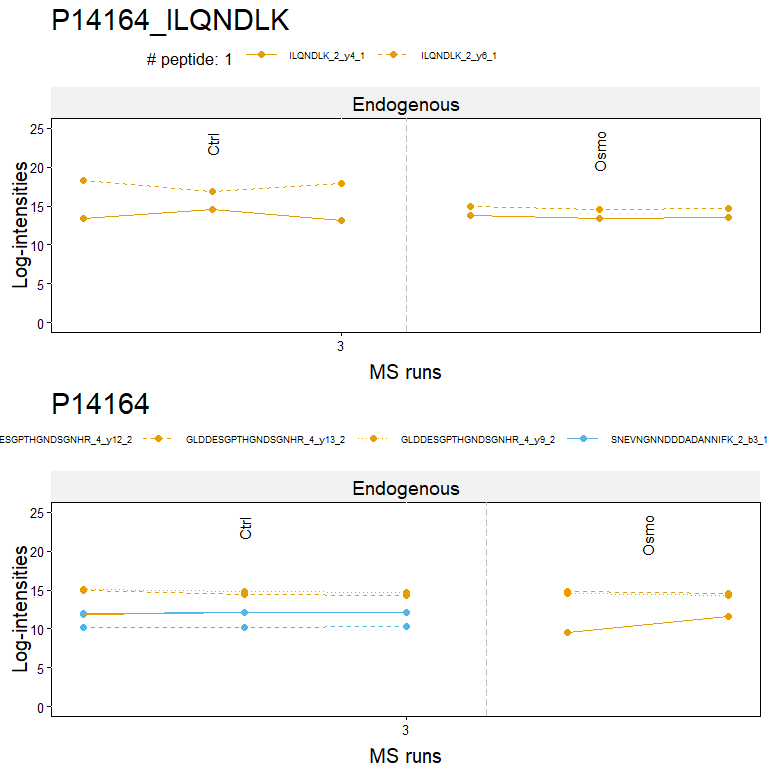

```
#> Drew the Profile plot for  P14164_ILQNDLK ( 1  of  1 )
```

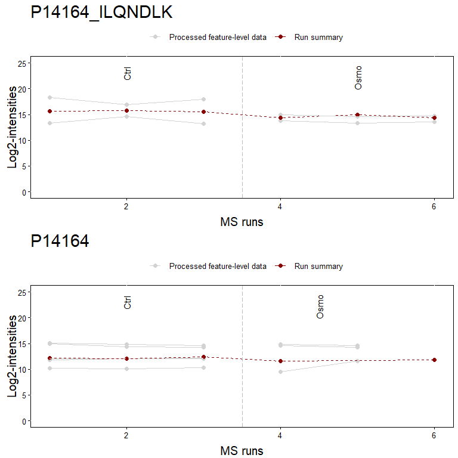

```r
dataProcessPlotsLiP(MSstatsLiP_Summarized,
                    type = 'ProfilePlot',
                    which.Peptide = c("P14164_ILQNDLK"),
                    address = FALSE)
```

#### 2.7 PCA Plot

In addition, Priciple Component Analysis can also be done on the summarized dataset. Three different PCA plots can be created one each for: Percent of explained variance per component, PC1 vs PC2 for peptides, and PC1 vs PC2 for conditions.

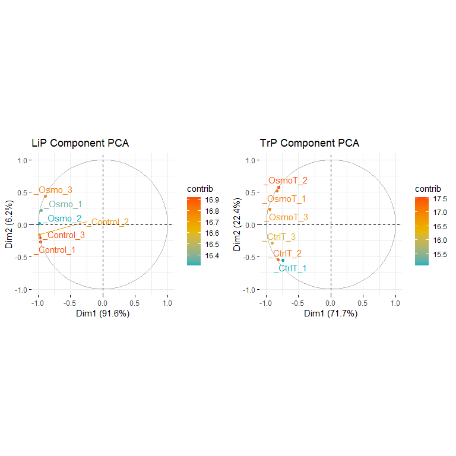

```r
PCAPlotLiP(MSstatsLiP_Summarized,
           bar.plot = FALSE,
           protein.pca = FALSE,
           comparison.pca = TRUE,
           which.comparison = c("Ctrl", "Osmo"),
           address=FALSE)
```

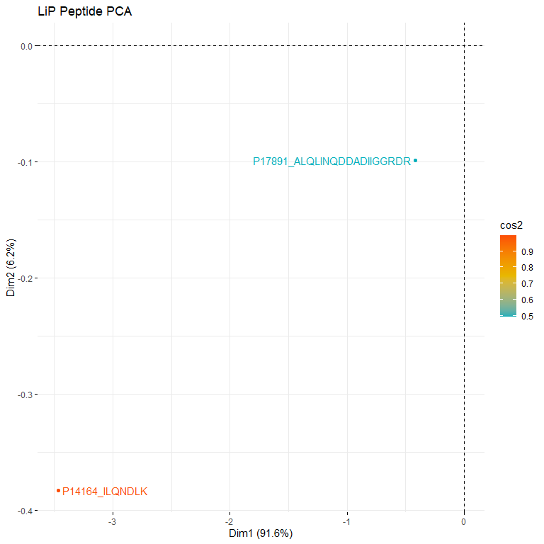

```r
PCAPlotLiP(MSstatsLiP_Summarized,
           bar.plot = FALSE,
           protein.pca = TRUE,
           comparison.pca = FALSE,
           which.pep = c("P14164_ILQNDLK", "P17891_ALQLINQDDADIIGGRDR"),
           address=FALSE)
```

#### 2.8 Calculate Trypticity

Finally, the trypticity of a peptide can also be calculated and added to any dataframe with the ProteinName and PeptideSequence column.

```r
feature_data <- data.table::copy(MSstatsLiP_Summarized$LiP$FeatureLevelData)
data.table::setnames(feature_data, c("PEPTIDE", "PROTEIN"),
                     c("PeptideSequence", "ProteinName"))
feature_data$PeptideSequence <- substr(feature_data$PeptideSequence, 1,
                                       nchar(as.character(
                                         feature_data$PeptideSequence)) - 2)

calculateTrypticity(feature_data, "../inst/extdata/ExampleFastaFile.fasta")
```

```
#>     ProteinName       PeptideSequence fully_TRI NSEMI_TRI CSEMI_TRI CTERMINUS
#>  1:      P14164               ILQNDLK      TRUE     FALSE     FALSE     FALSE
#>  2:      P16622 SHLQSNQLYSNQLPLDFALGK      TRUE     FALSE     FALSE     FALSE
#>  3:      P17891    ALQLINQDDADIIGGRDR      TRUE     FALSE     FALSE     FALSE
#>  4:      P17891              DDDTDFLK      TRUE     FALSE     FALSE     FALSE
#>  5:      P24004            FIGASEQNIR      TRUE     FALSE     FALSE     FALSE
#>  6:      P36112       SNDLLSGLTGSSQTR      TRUE     FALSE     FALSE     FALSE
#>  7:      P38805               LGQTVGR      TRUE     FALSE     FALSE     FALSE
#>  8:      P46959        DIIGKPYGSQIAIR      TRUE     FALSE     FALSE     FALSE
#>  9:      P52893           SSSQGVEGIRK     FALSE     FALSE      TRUE     FALSE
#> 10:      P52911          TWITEDDFEQIK      TRUE     FALSE     FALSE     FALSE
#> 11:      P53235      ERQAVGDKLEDTQVLK      TRUE     FALSE     FALSE     FALSE
#> 12:      P53858       FLDNHEVDSIVSLER      TRUE     FALSE     FALSE     FALSE
#> 13:      Q02908            ISVISGVGVR      TRUE     FALSE     FALSE     FALSE
#> 14:      Q12248            EFQSVSDLWK      TRUE     FALSE     FALSE     FALSE
#>     NTERMINUS StartPos EndPos
#>  1:     FALSE      358    365
#>  2:     FALSE      354    375
#>  3:     FALSE      196    214
#>  4:     FALSE       21     29
#>  5:     FALSE      770    780
#>  6:     FALSE      102    117
#>  7:     FALSE      205    212
#>  8:     FALSE       49     63
#>  9:     FALSE      221    232
#> 10:     FALSE      117    129
#> 11:     FALSE      607    623
#> 12:     FALSE      491    506
#> 13:     FALSE      528    538
#> 14:     FALSE       57     67
```

```r
MSstatsLiP_Summarized$LiP$FeatureLevelData%>%
  rename(PeptideSequence=PEPTIDE, ProteinName=PROTEIN)%>%
  mutate(PeptideSequence=substr(PeptideSequence, 1,
                                nchar(as.character(PeptideSequence))-2)
         ) %>% calculateTrypticity("../inst/extdata/ExampleFastaFile.fasta")
```

```
#>     ProteinName       PeptideSequence fully_TRI NSEMI_TRI CSEMI_TRI CTERMINUS
#>  1:      P14164               ILQNDLK      TRUE     FALSE     FALSE     FALSE
#>  2:      P16622 SHLQSNQLYSNQLPLDFALGK      TRUE     FALSE     FALSE     FALSE
#>  3:      P17891    ALQLINQDDADIIGGRDR      TRUE     FALSE     FALSE     FALSE
#>  4:      P17891              DDDTDFLK      TRUE     FALSE     FALSE     FALSE
#>  5:      P24004            FIGASEQNIR      TRUE     FALSE     FALSE     FALSE
#>  6:      P36112       SNDLLSGLTGSSQTR      TRUE     FALSE     FALSE     FALSE
#>  7:      P38805               LGQTVGR      TRUE     FALSE     FALSE     FALSE
#>  8:      P46959        DIIGKPYGSQIAIR      TRUE     FALSE     FALSE     FALSE
#>  9:      P52893           SSSQGVEGIRK     FALSE     FALSE      TRUE     FALSE
#> 10:      P52911          TWITEDDFEQIK      TRUE     FALSE     FALSE     FALSE
#> 11:      P53235      ERQAVGDKLEDTQVLK      TRUE     FALSE     FALSE     FALSE
#> 12:      P53858       FLDNHEVDSIVSLER      TRUE     FALSE     FALSE     FALSE
#> 13:      Q02908            ISVISGVGVR      TRUE     FALSE     FALSE     FALSE
#> 14:      Q12248            EFQSVSDLWK      TRUE     FALSE     FALSE     FALSE
#>     NTERMINUS StartPos EndPos
#>  1:     FALSE      358    365
#>  2:     FALSE      354    375
#>  3:     FALSE      196    214
#>  4:     FALSE       21     29
#>  5:     FALSE      770    780
#>  6:     FALSE      102    117
#>  7:     FALSE      205    212
#>  8:     FALSE       49     63
#>  9:     FALSE      221    232
#> 10:     FALSE      117    129
#> 11:     FALSE      607    623
#> 12:     FALSE      491    506
#> 13:     FALSE      528    538
#> 14:     FALSE       57     67
```